# Module 23

#### Hemi-module gene counts:

1167 probesets in hemi-module A.  
65 probesets in hemi-module B.  
Note: While the mapping of probesets to genes is usually one-to-one, some genes are targeted by multiple probesets, some probesets target multiple genes, and some probesets do not target any genes (i.e., the region of the genome they match is no longer considered genic).

#### Contrast SVE:

Signed variance explained (SVE) provides an indication of how similar a set of fold changes are to a gene module’s weight vector. An SVE value of 0.3, for example, indicates that 30% of the variance explained by the entire module set is accounted for by the module in question. Shown here are the SVE values for this module across a compendium of fold changes (contrasts). Extreme SVE values (e.g., > 0.05) indicate that those contrasts specifically induce (orange dots) or specifically repress (blue dots) this module. Examining the experimental conditions being compared in such contrasts (see tables below the figure) may provide insight into the gene module’s function.

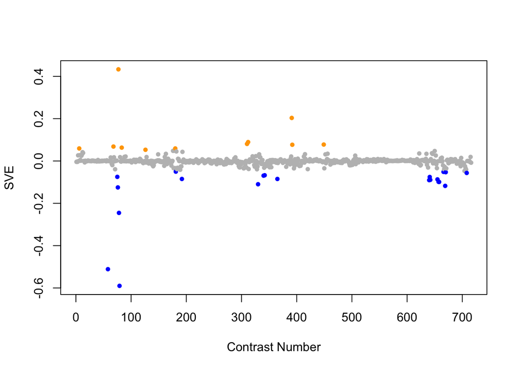

Positive SVE Contrasts:

|  | Contrast.Num | SVE | GEO.GSE | Cond.1 | Cond.2 | Mutation |
| --- | --- | --- | --- | --- | --- | --- |
| GSE8004.s3t2.vs.s1t2 | 77 | 0.43 | GSE8004 | Larval Pan-neural, biological rep 1 of set 2 | Larval A-class, biological rep 1 of set 3 |  |
| GSE32467.s1t1.vs.s0t1 | 391 | 0.20 | GSE32467 | unc-37(e262) A-class, biological rep1 | wildtype A-class, biological rep1 | unc-37 |
| GSE41056.s1t2.vs.s1t1 | 312 | 0.09 | GSE41056 | JU1580_inf_1 | JU1580_1 |  |
| GSE41056.s1t2.vs.s0t2 | 310 | 0.08 | GSE41056 | JU1580_inf_1 | N2_inf_1 |  |
| GSE25831.s1t1.vs.s2t1 | 449 | 0.08 | GSE25831 | WT_fedL1_rep1 | mixed embryo XX_WT-N_080307_A |  |
| GSE32339.s1t2.vs.s0t2 | 392 | 0.08 | GSE32339 | Adult Mutant, biological rep1 | Adult Wild-type, biological rep1 | nep-1 |
| GSE8462.s2t1.vs.s1t1 | 68 | 0.07 | GSE8462 | 0 hr Reference, biological rep 1 | 0 hr muscle, biological rep 1 |  |
| GSE6563.s1t1.vs.s0t1 | 83 | 0.06 | GSE6563 | daf19(m86)_daf12(sa204) replicate 1 | daf19(WT)_daf12(sa204) replicate 1 | daf-19 |
| GSE9897B.s3t1.vs.s0t1 | 6 | 0.06 | GSE9897 | Complex I RNAi Mutant 3 | Wildtype (control for RNAi) | C34B2.8 |
| GSE47778.s4t2.vs.s4t1 | 180 | 0.06 | GSE47778 | daf-2;daf-16; starvation; replicate 1 | daf-2;daf-16; replicate 1 |  |
| GSE54011.s1t1.vs.s0t1 | 126 | 0.05 | GSE54011 | Ce 0.05 mM Se | Ce 0 mM Se |  |

Negative SVE Contrasts:

|  | Contrast.Num | SVE | GEO.GSE | Cond.1 | Cond.2 | Mutation |
| --- | --- | --- | --- | --- | --- | --- |
| GSE8004.s2t2.vs.s3t2 | 79 | -0.59 | GSE8004 | Larval Reference, biological rep 1 of set 1 | Larval Pan-neural, biological rep 1 of set 2 |  |
| GSE9485.s2t1.vs.s1t1 | 58 | -0.51 | GSE9485 | Larval Reference, biological rep 1 | Larval Pan-neural, biological rep 1 |  |
| GSE8004.s2t2.vs.s1t2 | 78 | -0.25 | GSE8004 | Larval Reference, biological rep 1 of set 1 | Larval A-class, biological rep 1 of set 3 |  |
| GSE8004.s2t1.vs.s3t1 | 76 | -0.12 | GSE8004 | Embryonic Reference, biological rep 1 of set 1 | Embryonic Pan-neural, biological rep 1 of set 1 |  |
| GSE15016.s3t1.vs.s0t1 | 669 | -0.12 | GSE15016 | young adult_24hr DEHP exposure_rep1 | young adult_not exposured_rep1 |  |
| GSE38997.s4t4.vs.s2t4 | 330 | -0.11 | GSE38997 | experiment 1 UVC-exposed samples at 51 h 1u51 | experiment 1 EtBr-exposed samples at 51 h 1e51 |  |
| GSE16050.s0t2.vs.s0t1 | 658 | -0.10 | GSE16050 | WT_GFPm_rep1 | WT_GFPp_rep1 |  |
| GSE16050.s1t2.vs.s1t1 | 657 | -0.10 | GSE16050 | MT_GFPm_rep1 | MT_GFPp_rep1 |  |
| GSE18132.s2t2.vs.s2t1 | 640 | -0.09 | GSE18132 | Oga Fed L4, biological replicate 1 | Oga starved L1, biological replicate 1 |  |
| GSE18132.s0t2.vs.s0t1 | 642 | -0.09 | GSE18132 | WT Fed L4, biological rep1 | WT Starved L1, biological rep1 |  |
| GSE16050.s1t2.vs.s0t2 | 655 | -0.09 | GSE16050 | MT_GFPm_rep1 | WT_GFPm_rep1 |  |
| GSE36358.s3t1.vs.s0t1 | 365 | -0.08 | GSE36358 | Hyper Gravity | Ground Control (Tsukuba space center) |  |
| GSE45651.s1t1.vs.s0t1 | 192 | -0.08 | GSE45651 | starved L1 lin-35(n745), biological rep1 | starved L1 wild type worm, biological rep1 | lin-35 |
| GSE18132.s1t2.vs.s1t1 | 641 | -0.08 | GSE18132 | Ogt Fed L4, biological replicate 1 | Ogt starved L1, biological replicate 1 |  |
| GSE8159.s2t1.vs.s1t1 | 75 | -0.08 | GSE8159 | Embryonic Reference, biological rep 1 | Embryonic A-class, biological rep 1 |  |
| GSE38997.s4t1.vs.s1t1 | 340 | -0.07 | GSE38997 | experiment 4 UVC-exposed samples at 3 h 4u3 | experiment 4 control samples at 3 h 4c3 |  |
| GSE38997.s4t1.vs.s2t1 | 342 | -0.07 | GSE38997 | experiment 4 UVC-exposed samples at 3 h 4u3 | experiment 4 EtBr-exposed samples at 3 h 4e3 |  |
| GSE11055.s1t8.vs.s1t1 | 708 | -0.06 | GSE11055 | L2 larvae 24 hr after hatching in the presence of food | embryo 2 hr before hatching |  |
| GSE15016.s2t1.vs.s0t1 | 670 | -0.05 | GSE15016 | young adult_24hr NP exposure_rep1 | young adult_not exposured_rep1 |  |
| GSE15159.s0t2.vs.s0t1 | 666 | -0.05 | GSE15159 | N2_UV_2007_rep1 | N2_control_2007_rep1 |  |
| GSE47778.s4t3.vs.s4t1 | 181 | -0.05 | GSE47778 | daf-2;daf-16; UV; replicate 1 | daf-2;daf-16; replicate 1 |  |

$~$

#### Contrast SVE, Up-Regulated Genes Only:

Calculating SVE for up-regulated and down-regulated genes separately may be more informative in many cases than projecting the up- and down- gene sets together. This is due to the fact that the weight distribution of many modules is highly skewed, indicating that only one of the hemi-modules may be biologically meaningful (i.e., a set of genes are strongly correlated by only a few genes (or none) are strongly anti-correlated to that set.)

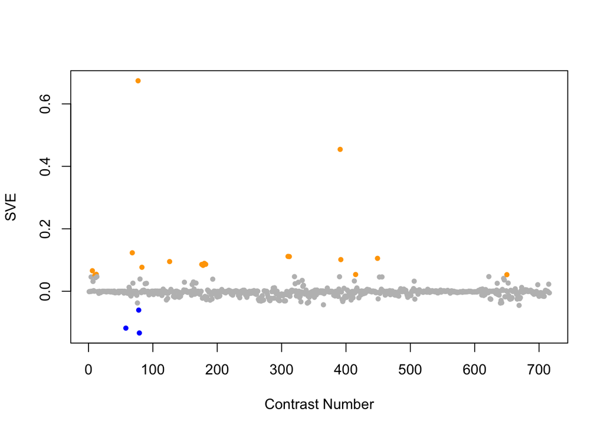

Positive SVE Contrasts:

|  | Contrast.Num | SVE | GEO.GSE | Cond.1 | Cond.2 | Mutation |
| --- | --- | --- | --- | --- | --- | --- |
| GSE8004.s3t2.vs.s1t2 | 77 | 0.67 | GSE8004 | Larval Pan-neural, biological rep 1 of set 2 | Larval A-class, biological rep 1 of set 3 |  |
| GSE32467.s1t1.vs.s0t1 | 391 | 0.45 | GSE32467 | unc-37(e262) A-class, biological rep1 | wildtype A-class, biological rep1 | unc-37 |
| GSE8462.s2t1.vs.s1t1 | 68 | 0.12 | GSE8462 | 0 hr Reference, biological rep 1 | 0 hr muscle, biological rep 1 |  |
| GSE41056.s1t2.vs.s0t2 | 310 | 0.11 | GSE41056 | JU1580_inf_1 | N2_inf_1 |  |
| GSE41056.s1t2.vs.s1t1 | 312 | 0.11 | GSE41056 | JU1580_inf_1 | JU1580_1 |  |
| GSE25831.s1t1.vs.s2t1 | 449 | 0.11 | GSE25831 | WT_fedL1_rep1 | mixed embryo XX_WT-N_080307_A |  |
| GSE32339.s1t2.vs.s0t2 | 392 | 0.10 | GSE32339 | Adult Mutant, biological rep1 | Adult Wild-type, biological rep1 | nep-1 |
| GSE54011.s1t1.vs.s0t1 | 126 | 0.10 | GSE54011 | Ce 0.05 mM Se | Ce 0 mM Se |  |
| GSE47778.s4t2.vs.s4t1 | 180 | 0.09 | GSE47778 | daf-2;daf-16; starvation; replicate 1 | daf-2;daf-16; replicate 1 |  |
| GSE47778.s1t2.vs.s1t1 | 182 | 0.09 | GSE47778 | N2; starvation; replicate 1 | N2; replicate 1 |  |
| GSE47778.s3t2.vs.s3t1 | 176 | 0.09 | GSE47778 | daf-16; starvation; replicate 1 | daf-16; replicate 1 |  |
| GSE47778.s2t2.vs.s2t1 | 178 | 0.08 | GSE47778 | daf-2; starvation; replicate 1 | daf-2; replicate 1 |  |
| GSE6563.s1t1.vs.s0t1 | 83 | 0.08 | GSE6563 | daf19(m86)_daf12(sa204) replicate 1 | daf19(WT)_daf12(sa204) replicate 1 | daf-19 |
| GSE9897B.s3t1.vs.s0t1 | 6 | 0.07 | GSE9897 | Complex I RNAi Mutant 3 | Wildtype (control for RNAi) | C34B2.8 |
| GSE9682.s1t2.vs.s0t2 | 12 | 0.05 | GSE9682 | N2-Cel-RhebRNAi-fed-biological rep1 | N2-controlRNAi-fed-biological rep1 | Rheb |
| GSE29951.s1t2.vs.s1t1 | 415 | 0.05 | GSE29951 | C.elegans MT KO mtl-1,mtl-2(zs1) raised in the presence of Cd, rep1 | C.elegans MT KO mtl-1,mtl-2(zs1), raised in the absence of Cd, rep1 | mtl-1;mtl-2 |
| GSE16405.s3t1.vs.s1t1 | 650 | 0.05 | GSE16405 | nth-1;xpa-1_1 | N2_1 | nth-1;xpa-1 |
| GSE9682.s1t1.vs.s0t1 | 10 | 0.05 | GSE9682 | N2-Cel-RhebRNAi-fasting-biological rep1 | N2-controlRNAi-fasting-biological rep1 | Rheb |

Negative SVE Contrasts:

|  | Contrast.Num | SVE | GEO.GSE | Cond.1 | Cond.2 | Mutation |
| --- | --- | --- | --- | --- | --- | --- |
| GSE8004.s2t2.vs.s3t2 | 79 | -0.13 | GSE8004 | Larval Reference, biological rep 1 of set 1 | Larval Pan-neural, biological rep 1 of set 2 |  |
| GSE9485.s2t1.vs.s1t1 | 58 | -0.12 | GSE9485 | Larval Reference, biological rep 1 | Larval Pan-neural, biological rep 1 |  |
| GSE8004.s2t2.vs.s1t2 | 78 | -0.06 | GSE8004 | Larval Reference, biological rep 1 of set 1 | Larval A-class, biological rep 1 of set 3 |  |
| GSE15016.s3t1.vs.s0t1 | 669 | -0.05 | GSE15016 | young adult_24hr DEHP exposure_rep1 | young adult_not exposured_rep1 |  |
| GSE36358.s3t1.vs.s0t1 | 365 | -0.04 | GSE36358 | Hyper Gravity | Ground Control (Tsukuba space center) |  |

$~$

#### Contrast SVE, Down-Regulated Genes Only:

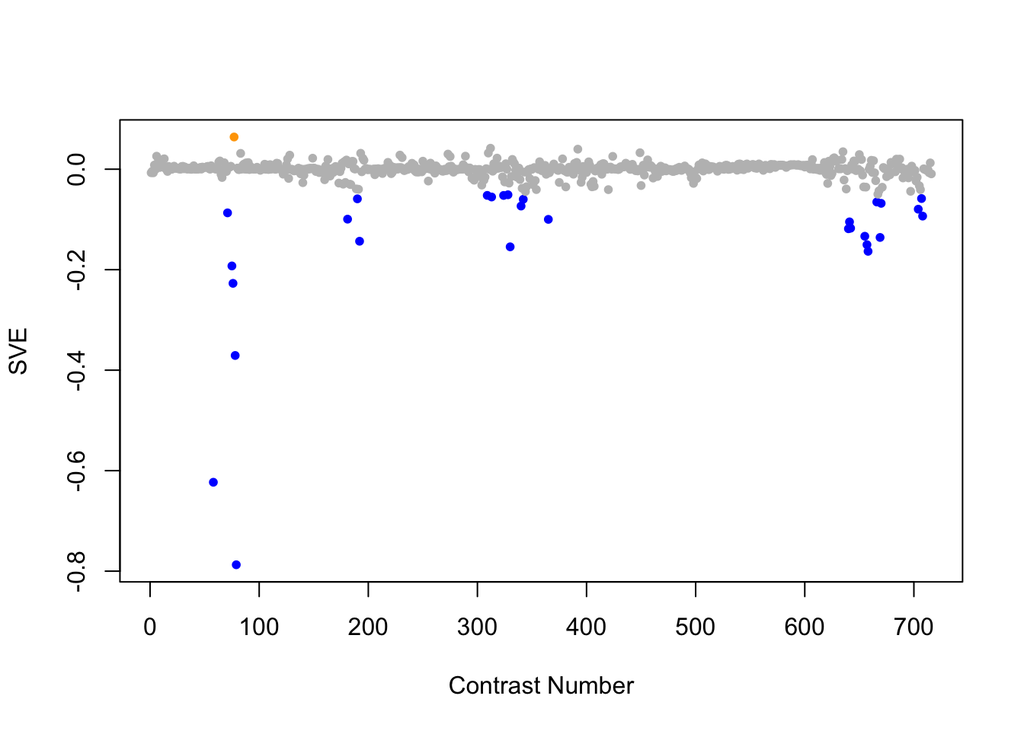

Positive SVE Contrasts:

|  | Contrast.Num | SVE | GEO.GSE | Cond.1 | Cond.2 | Mutation |
| --- | --- | --- | --- | --- | --- | --- |
| GSE8004.s3t2.vs.s1t2 | 77 | 0.06 | GSE8004 | Larval Pan-neural, biological rep 1 of set 2 | Larval A-class, biological rep 1 of set 3 |  |
| GSE41056.s1t2.vs.s1t1 | 312 | 0.04 | GSE41056 | JU1580_inf_1 | JU1580_1 |  |
| GSE32339.s1t2.vs.s0t2 | 392 | 0.04 | GSE32339 | Adult Mutant, biological rep1 | Adult Wild-type, biological rep1 | nep-1 |
| GSE18157.s1t1.vs.s0t1 | 635 | 0.03 | GSE18157 | Caenorhabditis elegans in biotin deficiency 1 | Caenorhabditis elegans grown with sufficient Biotin 1 |  |
| GSE25831.s1t1.vs.s2t1 | 449 | 0.03 | GSE25831 | WT_fedL1_rep1 | mixed embryo XX_WT-N_080307_A |  |

Negative SVE Contrasts:

|  | Contrast.Num | SVE | GEO.GSE | Cond.1 | Cond.2 | Mutation |
| --- | --- | --- | --- | --- | --- | --- |
| GSE8004.s2t2.vs.s3t2 | 79 | -0.79 | GSE8004 | Larval Reference, biological rep 1 of set 1 | Larval Pan-neural, biological rep 1 of set 2 |  |
| GSE9485.s2t1.vs.s1t1 | 58 | -0.62 | GSE9485 | Larval Reference, biological rep 1 | Larval Pan-neural, biological rep 1 |  |
| GSE8004.s2t2.vs.s1t2 | 78 | -0.37 | GSE8004 | Larval Reference, biological rep 1 of set 1 | Larval A-class, biological rep 1 of set 3 |  |
| GSE8004.s2t1.vs.s3t1 | 76 | -0.23 | GSE8004 | Embryonic Reference, biological rep 1 of set 1 | Embryonic Pan-neural, biological rep 1 of set 1 |  |
| GSE8159.s2t1.vs.s1t1 | 75 | -0.19 | GSE8159 | Embryonic Reference, biological rep 1 | Embryonic A-class, biological rep 1 |  |
| GSE16050.s0t2.vs.s0t1 | 658 | -0.16 | GSE16050 | WT_GFPm_rep1 | WT_GFPp_rep1 |  |
| GSE38997.s4t4.vs.s2t4 | 330 | -0.15 | GSE38997 | experiment 1 UVC-exposed samples at 51 h 1u51 | experiment 1 EtBr-exposed samples at 51 h 1e51 |  |
| GSE16050.s1t2.vs.s1t1 | 657 | -0.15 | GSE16050 | MT_GFPm_rep1 | MT_GFPp_rep1 |  |
| GSE45651.s1t1.vs.s0t1 | 192 | -0.14 | GSE45651 | starved L1 lin-35(n745), biological rep1 | starved L1 wild type worm, biological rep1 | lin-35 |
| GSE15016.s3t1.vs.s0t1 | 669 | -0.14 | GSE15016 | young adult_24hr DEHP exposure_rep1 | young adult_not exposured_rep1 |  |
| GSE16050.s1t2.vs.s0t2 | 655 | -0.13 | GSE16050 | MT_GFPm_rep1 | WT_GFPm_rep1 |  |
| GSE18132.s2t2.vs.s2t1 | 640 | -0.12 | GSE18132 | Oga Fed L4, biological replicate 1 | Oga starved L1, biological replicate 1 |  |
| GSE18132.s0t2.vs.s0t1 | 642 | -0.12 | GSE18132 | WT Fed L4, biological rep1 | WT Starved L1, biological rep1 |  |
| GSE18132.s1t2.vs.s1t1 | 641 | -0.10 | GSE18132 | Ogt Fed L4, biological replicate 1 | Ogt starved L1, biological replicate 1 |  |
| GSE36358.s3t1.vs.s0t1 | 365 | -0.10 | GSE36358 | Hyper Gravity | Ground Control (Tsukuba space center) |  |
| GSE47778.s4t3.vs.s4t1 | 181 | -0.10 | GSE47778 | daf-2;daf-16; UV; replicate 1 | daf-2;daf-16; replicate 1 |  |
| GSE11055.s1t8.vs.s1t1 | 708 | -0.09 | GSE11055 | L2 larvae 24 hr after hatching in the presence of food | embryo 2 hr before hatching |  |
| GSE8462.s2t2.vs.s2t1 | 71 | -0.09 | GSE8462 | 24 hr Reference, biological rep 1 | 0 hr Reference, biological rep 1 |  |
| GSE11055.s1t6.vs.s1t1 | 704 | -0.08 | GSE11055 | L1 larvae 12 hr after hatching in the presence of food | embryo 2 hr before hatching |  |
| GSE38997.s4t1.vs.s1t1 | 340 | -0.07 | GSE38997 | experiment 4 UVC-exposed samples at 3 h 4u3 | experiment 4 control samples at 3 h 4c3 |  |
| GSE15016.s2t1.vs.s0t1 | 670 | -0.07 | GSE15016 | young adult_24hr NP exposure_rep1 | young adult_not exposured_rep1 |  |
| GSE15159.s0t2.vs.s0t1 | 666 | -0.07 | GSE15159 | N2_UV_2007_rep1 | N2_control_2007_rep1 |  |
| GSE38997.s4t1.vs.s2t1 | 342 | -0.06 | GSE38997 | experiment 4 UVC-exposed samples at 3 h 4u3 | experiment 4 EtBr-exposed samples at 3 h 4e3 |  |
| GSE46291.s1t2.vs.s1t1 | 190 | -0.06 | GSE46291 | L4_rep1 | L3_rep1 |  |
| GSE11055.s1t7.vs.s1t1 | 707 | -0.06 | GSE11055 | L1-L2 larvae 15 hr after hatching in the presence of food | embryo 2 hr before hatching |  |
| GSE41056.s0t2.vs.s0t1 | 313 | -0.06 | GSE41056 | N2_inf_1 | N2_1 |  |
| GSE38997.s4t3.vs.s2t3 | 324 | -0.05 | GSE38997 | experiment 1 UVC-exposed samples at 48 h 1u48 | experiment 1 EtBr-exposed samples at 48 h 1e48 |  |
| GSE41056.s2t1.vs.s0t1 | 309 | -0.05 | GSE41056 | RDE_1_1 | N2_1 | rde-1 |
| GSE38997.s4t4.vs.s1t4 | 328 | -0.05 | GSE38997 | experiment 1 UVC-exposed samples at 51 h 1u51 | experiment 1 control samples at 51 h 1c51 |  |

$~$

$~$

#### GO Term Enrichment:

This analysis tests each hemi-module for enrichment of specific GO terms. Only gene-level annotations (e.g., as would be found on the gene’s page in Wormbase) are tested - the hierarchical structure of the GO ontology is not taken into account.

*Note: At least the top two most enriched terms from each GO domain (BP/MF/CC) are shown, even when not statistically significant.*

##### Enriched GO terms: Hemi-module A

| ID | GO.Term | GO Domain | Raw p-value | Adj p-value |
| --- | --- | --- | --- | --- |
| [GO_0007218](http://amigo.geneontology.org/amigo/term/GO:0007218) | neuropeptide signaling pathway | BP | 1.10e-46 | 4.01e-43 |
| [GO_0007165](http://amigo.geneontology.org/amigo/term/GO:0007165) | signal transduction | BP | 1.89e-43 | 3.45e-40 |
| [GO_0007268](http://amigo.geneontology.org/amigo/term/GO:0007268) | chemical synaptic transmission | BP | 3.50e-36 | 4.25e-33 |
| [GO_0034220](http://amigo.geneontology.org/amigo/term/GO:0034220) | ion transmembrane transport | BP | 1.03e-30 | 9.38e-28 |
| [GO_0006811](http://amigo.geneontology.org/amigo/term/GO:0006811) | ion transport | BP | 7.64e-30 | 5.57e-27 |
| [GO_0042391](http://amigo.geneontology.org/amigo/term/GO:0042391) | regulation of membrane potential | BP | 1.64e-25 | 9.98e-23 |
| [GO_0050877](http://amigo.geneontology.org/amigo/term/GO:0050877) | nervous system process | BP | 3.73e-25 | 1.94e-22 |
| [GO_0007186](http://amigo.geneontology.org/amigo/term/GO:0007186) | G protein-coupled receptor signaling pathway | BP | 2.59e-14 | 1.18e-11 |
| [GO_0071805](http://amigo.geneontology.org/amigo/term/GO:0071805) | potassium ion transmembrane transport | BP | 1.50e-10 | 6.07e-08 |
| [GO_0060078](http://amigo.geneontology.org/amigo/term/GO:0060078) | regulation of postsynaptic membrane potential | BP | 2.88e-10 | 1.05e-07 |
| [GO_0001966](http://amigo.geneontology.org/amigo/term/GO:0001966) | thigmotaxis | BP | 6.19e-10 | 2.05e-07 |
| [GO_0098664](http://amigo.geneontology.org/amigo/term/GO:0098664) | G protein-coupled serotonin receptor signaling pathway | BP | 6.60e-09 | 2.00e-06 |
| [GO_0055114](http://amigo.geneontology.org/amigo/term/GO:0055114) | oxidation-reduction process | BP | 2.16e-08 | 6.07e-06 |
| [GO_0071277](http://amigo.geneontology.org/amigo/term/GO:0071277) | cellular response to calcium ion | BP | 3.75e-08 | 9.75e-06 |
| [GO_1902476](http://amigo.geneontology.org/amigo/term/GO:1902476) | chloride transmembrane transport | BP | 5.44e-08 | 1.32e-05 |
| [GO_0007187](http://amigo.geneontology.org/amigo/term/GO:0007187) | G protein-coupled receptor signaling pathway, coupled to cyclic nucleotide second messenger | BP | 6.29e-08 | 1.43e-05 |
| [GO_0009612](http://amigo.geneontology.org/amigo/term/GO:0009612) | response to mechanical stimulus | BP | 7.90e-08 | 1.61e-05 |
| [GO_0014059](http://amigo.geneontology.org/amigo/term/GO:0014059) | regulation of dopamine secretion | BP | 8.42e-08 | 1.61e-05 |
| [GO_0017158](http://amigo.geneontology.org/amigo/term/GO:0017158) | regulation of calcium ion-dependent exocytosis | BP | 8.42e-08 | 1.61e-05 |
| [GO_0061096](http://amigo.geneontology.org/amigo/term/GO:0061096) | negative regulation of turning behavior involved in mating | BP | 1.25e-07 | 2.28e-05 |
| [GO_0007271](http://amigo.geneontology.org/amigo/term/GO:0007271) | synaptic transmission, cholinergic | BP | 2.26e-07 | 3.74e-05 |
| [GO_0060079](http://amigo.geneontology.org/amigo/term/GO:0060079) | excitatory postsynaptic potential | BP | 2.26e-07 | 3.74e-05 |
| [GO_0017156](http://amigo.geneontology.org/amigo/term/GO:0017156) | calcium ion regulated exocytosis | BP | 2.37e-07 | 3.75e-05 |
| [GO_0016079](http://amigo.geneontology.org/amigo/term/GO:0016079) | synaptic vesicle exocytosis | BP | 8.73e-07 | 1.32e-04 |
| [GO_0030322](http://amigo.geneontology.org/amigo/term/GO:0030322) | stabilization of membrane potential | BP | 2.05e-06 | 2.99e-04 |
| [GO_0006813](http://amigo.geneontology.org/amigo/term/GO:0006813) | potassium ion transport | BP | 2.74e-06 | 3.84e-04 |
| [GO_0007626](http://amigo.geneontology.org/amigo/term/GO:0007626) | locomotory behavior | BP | 3.57e-06 | 4.82e-04 |
| [GO_0045087](http://amigo.geneontology.org/amigo/term/GO:0045087) | innate immune response | BP | 4.21e-06 | 5.47e-04 |
| [GO_0042493](http://amigo.geneontology.org/amigo/term/GO:0042493) | response to drug | BP | 8.43e-06 | 1.06e-03 |
| [GO_0046928](http://amigo.geneontology.org/amigo/term/GO:0046928) | regulation of neurotransmitter secretion | BP | 1.00e-05 | 1.21e-03 |

[output cut: 145 more lines]

##### Enriched GO terms: Hemi-module B

| ID | GO.Term | GO Domain | Raw p-value | Adj p-value |
| --- | --- | --- | --- | --- |
| [GO_0008615](http://amigo.geneontology.org/amigo/term/GO:0008615) | pyridoxine biosynthetic process | BP | 4.07e-03 | 9.99e-01 |
| [GO_0010644](http://amigo.geneontology.org/amigo/term/GO:0010644) | cell communication by electrical coupling | BP | 4.07e-03 | 9.99e-01 |
| [GO_0004032](http://amigo.geneontology.org/amigo/term/GO:0004032) | alditol:NADP+ 1-oxidoreductase activity | MF | 8.73e-04 | 7.56e-01 |
| [GO_0008106](http://amigo.geneontology.org/amigo/term/GO:0008106) | alcohol dehydrogenase (NADP+) activity | MF | 1.04e-03 | 7.56e-01 |
| [GO_0005829](http://amigo.geneontology.org/amigo/term/GO:0005829) | cytosol | CC | 1.41e-03 | 9.45e-01 |
| [GO_0015629](http://amigo.geneontology.org/amigo/term/GO:0015629) | actin cytoskeleton | CC | 2.38e-03 | 9.45e-01 |

$~$

$~$

#### Tissue Enrichment:

This analysis tests each hemi-module for enrichment of genes associated with anatomy terms. Negative enrichment scores indicate fewer hemi-module genes than expected by random chance were associated with the anatomy term in question.

##### Enriched tissues: Hemi-module A

| ID | Anatomy.Term | Definition | Raw p-value | Adj p-value |
| --- | --- | --- | --- | --- |
| [WBbt_0006749](https://wormbase.org/species/all/anatomy_term/WBbt:0006749) | nerve ring | the most extensive region of neuropil in the animal, consists of a large toroidal bundle of processes. | 1.13e-24 | 2.74e-21 |
| [WBbt_0006759](https://wormbase.org/species/all/anatomy_term/WBbt:0006759) | tail neuron | neuron with its cell body situated in the tail, posterior to rectum. | 6.07e-23 | 7.38e-20 |
| [WBbt_0005300](https://wormbase.org/species/all/anatomy_term/WBbt:0005300) | ventral cord neuron | neuron with cell body associated with the ventral nerve cord. | 5.40e-22 | 4.38e-19 |
| [WBbt_0005339](https://wormbase.org/species/all/anatomy_term/WBbt:0005339) | VA neuron | Neuron class of twelve motoneurons, distributed along the ventral cord, which innervate ventral body muscles. | 1.03e-19 | 6.24e-17 |
| [WBbt_0005336](https://wormbase.org/species/all/anatomy_term/WBbt:0005336) | VB neuron | Neuron class of eleven motoneurons, distributed along the ventral cord, which innervate ventral body muscles. | 1.59e-18 | 7.76e-16 |
| [WBbt_0005274](https://wormbase.org/species/all/anatomy_term/WBbt:0005274) | DB neuron | Neuron class of seven motoneurons that innervate dorsal muscles and have cell bodies in the ventral cord. | 5.95e-18 | 2.41e-15 |
| [WBbt_0005278](https://wormbase.org/species/all/anatomy_term/WBbt:0005278) | DA neuron | Neuron class of nine ventral cord motor neuron, innervates dorsal muscle. | 3.33e-17 | 1.16e-14 |
| [WBbt_0005270](https://wormbase.org/species/all/anatomy_term/WBbt:0005270) | DD neuron | Neuron class of six motoneurons, with cell bodies in the ventral cord, which innervate dorsal muscles. Each cell has a short, posteriorly directed and a longer, anteriorly directed process emanating f… | 5.01e-17 | 1.52e-14 |
| [WBbt_0005829](https://wormbase.org/species/all/anatomy_term/WBbt:0005829) | ventral nerve cord | a large process bundle that runs along the vental mid-line extending from the ventral region of the nerve ring. | 6.31e-17 | 1.71e-14 |
| [WBbt_0003679](https://wormbase.org/species/all/anatomy_term/WBbt:0003679) | neuron | Major cell type of nervous tissue, specialized for transmission of information in the form of patterns of impulses. | 9.22e-17 | 2.24e-14 |
| [WBbt_0005303](https://wormbase.org/species/all/anatomy_term/WBbt:0005303) | VD neuron | Neuron class of thirteen motoneurons, with cell bodies in the ventral cord, which innervate ventral muscles. Each cell has an anteriorly directed process emanating from its cell body. | 6.15e-16 | 1.36e-13 |
| [WBbt_0004797](https://wormbase.org/species/all/anatomy_term/WBbt:0004797) | FLPR | Neuron, ciliated ending in head, no supporting cells, associated with ILso | 1.14e-15 | 2.14e-13 |
| [WBbt_0004798](https://wormbase.org/species/all/anatomy_term/WBbt:0004798) | FLPL | Neuron, ciliated ending in head, no supporting cells, associated with ILso | 1.14e-15 | 2.14e-13 |
| [WBbt_0004970](https://wormbase.org/species/all/anatomy_term/WBbt:0004970) | SMDVL | Ring motor neuron/interneuron, has a posteriorly direct ed process that runs sublaterally | 5.13e-15 | 8.91e-13 |
| [WBbt_0003963](https://wormbase.org/species/all/anatomy_term/WBbt:0003963) | AIYL | Amphid interneuron | 6.90e-15 | 1.12e-12 |
| [WBbt_0004969](https://wormbase.org/species/all/anatomy_term/WBbt:0004969) | SMDVR | Ring motor neuron/interneuron, has a posteriorly direct ed process that runs sublaterally | 1.04e-14 | 1.58e-12 |
| [WBbt_0003961](https://wormbase.org/species/all/anatomy_term/WBbt:0003961) | AIYR | Amphid interneuron | 4.34e-14 | 6.21e-12 |
| [WBbt_0006751](https://wormbase.org/species/all/anatomy_term/WBbt:0006751) | head neuron | neuron with its cell body situated in the head, excluding the pharynx. | 5.30e-14 | 7.17e-12 |
| [WBbt_0004103](https://wormbase.org/species/all/anatomy_term/WBbt:0004103) | PLMR | Posterior lateral microtubule cell, touch receptor | 8.30e-14 | 1.06e-11 |
| [WBbt_0004104](https://wormbase.org/species/all/anatomy_term/WBbt:0004104) | PLML | Posterior lateral microtubule cell, touch receptor | 1.17e-13 | 1.43e-11 |
| [WBbt_0004997](https://wormbase.org/species/all/anatomy_term/WBbt:0004997) | SABVR | Ring interneuron, anteriorly projecting process that runs sublaterally, synapses to anterior body muscles in L1 | 2.88e-13 | 3.05e-11 |
| [WBbt_0004998](https://wormbase.org/species/all/anatomy_term/WBbt:0004998) | SABVL | Ring interneuron, anteriorly projecting process that runs sublaterally, synapses to anterior body muscles in L1 | 2.88e-13 | 3.05e-11 |
| [WBbt_0004999](https://wormbase.org/species/all/anatomy_term/WBbt:0004999) | SABD | Ring interneuron, anteriorly projecting process that runs sublaterally, synapses to anterior body muscles in L1 | 2.88e-13 | 3.05e-11 |
| [WBbt_0004094](https://wormbase.org/species/all/anatomy_term/WBbt:0004094) | PVCL | Ventral cord interneuron, cell body in lumbar ganglion, synapses onto VB and DB motor neurons, formerly called delta. | 4.08e-13 | 4.14e-11 |
| [WBbt_0004092](https://wormbase.org/species/all/anatomy_term/WBbt:0004092) | PVCR | Ventral cord interneuron, cell body in lumbar ganglion, synapses onto VB and DB motor neurons, formerly called delta. | 7.41e-13 | 6.73e-11 |
| [WBbt_0004972](https://wormbase.org/species/all/anatomy_term/WBbt:0004972) | SMDDL | Ring motor neuron/interneuron, has a posteriorly direct ed process that runs sublaterally | 7.41e-13 | 6.73e-11 |
| [WBbt_0006840](https://wormbase.org/species/all/anatomy_term/WBbt:0006840) | cholinergic neuron | neuron that uses vesicular acetylcholine as a neurotransmitter. | 7.90e-13 | 6.73e-11 |
| [WBbt_0004088](https://wormbase.org/species/all/anatomy_term/WBbt:0004088) | PVDR | Neuron, lateral process adjacent to excretory canal | 8.14e-13 | 6.73e-11 |
| [WBbt_0004090](https://wormbase.org/species/all/anatomy_term/WBbt:0004090) | PVDL | Neuron, lateral process adjacent to excretory canal | 8.14e-13 | 6.73e-11 |
| [WBbt_0003953](https://wormbase.org/species/all/anatomy_term/WBbt:0003953) | ALMR | Anterior lateral microtubule cell, touch receptor | 8.30e-13 | 6.73e-11 |

[output cut: 246 more lines]

##### Enriched tissues: Hemi-module B

No significant annotations.

$~$

$~$

#### HOMER promoter motif enrichment:

This analysis tests each hemi-module for enrichment of 108 known *C. elegans* transcription factor binding site motifs (see [108 CE motifs](https://katiepod.github.io//all.worm.motifs.html)) using the HOMER (Hypergeometric Optimization of Motif EnRichment) software (see [PMID:20513432](https://pubmed.ncbi.nlm.nih.gov/20513432)). HOMER was run using default parameters on sequences 1 kb upstream of the transcription start site.

##### Motif enrichment: Hemi-module A

Total target sequences = 999  
Total background sequences = 39544  
* - possible false positive

Rank

Motif

P-value

log P-pvalue

% of Targets

% of Background

STD(Bg STD)

Best Match/Details

Motif File

1

[figure not shown]

1e-26

-6.215e+01

49.25%

32.39%

291.7bp (343.0bp)

blmp-1/MA0537.1/Jaspar(0.647)  
[More Information](https://katiepod.github.io/HomerResults/m23_a_hemi_genes.txt.out.1kb/homerResults/motif1.info.html) | [Similar Motifs Found](https://katiepod.github.io/HomerResults/m23_a_hemi_genes.txt.out.1kb/homerResults/motif1.similar.html)

[motif file (matrix)](https://katiepod.github.io/HomerResults/m23_a_hemi_genes.txt.out.1kb/homerResults/motif1.motif)

2

[figure not shown]

1e-23

-5.446e+01

22.22%

10.85%

279.8bp (345.4bp)

POL003.1_GC-box/Jaspar(0.852)  
[More Information](https://katiepod.github.io/HomerResults/m23_a_hemi_genes.txt.out.1kb/homerResults/motif2.info.html) | [Similar Motifs Found](https://katiepod.github.io/HomerResults/m23_a_hemi_genes.txt.out.1kb/homerResults/motif2.similar.html)

[motif file (matrix)](https://katiepod.github.io/HomerResults/m23_a_hemi_genes.txt.out.1kb/homerResults/motif2.motif)

3

[figure not shown]

1e-17

-4.066e+01

11.51%

4.59%

282.8bp (325.1bp)

POL006.1_BREu/Jaspar(0.656)  
[More Information](https://katiepod.github.io/HomerResults/m23_a_hemi_genes.txt.out.1kb/homerResults/motif3.info.html) | [Similar Motifs Found](https://katiepod.github.io/HomerResults/m23_a_hemi_genes.txt.out.1kb/homerResults/motif3.similar.html)

[motif file (matrix)](https://katiepod.github.io/HomerResults/m23_a_hemi_genes.txt.out.1kb/homerResults/motif3.motif)

4

[figure not shown]

1e-15

-3.562e+01

2.40%

0.22%

273.0bp (369.5bp)

POL003.1_GC-box/Jaspar(0.580)  
[More Information](https://katiepod.github.io/HomerResults/m23_a_hemi_genes.txt.out.1kb/homerResults/motif4.info.html) | [Similar Motifs Found](https://katiepod.github.io/HomerResults/m23_a_hemi_genes.txt.out.1kb/homerResults/motif4.similar.html)

[motif file (matrix)](https://katiepod.github.io/HomerResults/m23_a_hemi_genes.txt.out.1kb/homerResults/motif4.motif)

5

[figure not shown]

1e-14

-3.379e+01

30.63%

19.96%

287.2bp (359.2bp)

POL008.1_DCE_S_I/Jaspar(0.638)  
[More Information](https://katiepod.github.io/HomerResults/m23_a_hemi_genes.txt.out.1kb/homerResults/motif5.info.html) | [Similar Motifs Found](https://katiepod.github.io/HomerResults/m23_a_hemi_genes.txt.out.1kb/homerResults/motif5.similar.html)

[motif file (matrix)](https://katiepod.github.io/HomerResults/m23_a_hemi_genes.txt.out.1kb/homerResults/motif5.motif)

6

[figure not shown]

1e-14

-3.335e+01

29.33%

18.92%

282.3bp (319.1bp)

PL0008.1_hlh-29/Jaspar(0.645)  
[More Information](https://katiepod.github.io/HomerResults/m23_a_hemi_genes.txt.out.1kb/homerResults/motif6.info.html) | [Similar Motifs Found](https://katiepod.github.io/HomerResults/m23_a_hemi_genes.txt.out.1kb/homerResults/motif6.similar.html)

[motif file (matrix)](https://katiepod.github.io/HomerResults/m23_a_hemi_genes.txt.out.1kb/homerResults/motif6.motif)

7

[figure not shown]

1e-14

-3.315e+01

31.33%

20.66%

294.4bp (331.1bp)

ELT-3(Gata)/cElegans-L1-ELT3-ChIP-Seq(modEncode)/Homer(0.735)  
[More Information](https://katiepod.github.io/HomerResults/m23_a_hemi_genes.txt.out.1kb/homerResults/motif7.info.html) | [Similar Motifs Found](https://katiepod.github.io/HomerResults/m23_a_hemi_genes.txt.out.1kb/homerResults/motif7.similar.html)

[motif file (matrix)](https://katiepod.github.io/HomerResults/m23_a_hemi_genes.txt.out.1kb/homerResults/motif7.motif)

8

[figure not shown]

1e-14

-3.266e+01

12.01%

5.50%

317.3bp (335.5bp)

MF0001.1_ETS_class/Jaspar(0.706)  
[More Information](https://katiepod.github.io/HomerResults/m23_a_hemi_genes.txt.out.1kb/homerResults/motif8.info.html) | [Similar Motifs Found](https://katiepod.github.io/HomerResults/m23_a_hemi_genes.txt.out.1kb/homerResults/motif8.similar.html)

[motif file (matrix)](https://katiepod.github.io/HomerResults/m23_a_hemi_genes.txt.out.1kb/homerResults/motif8.motif)

9

[figure not shown]

1e-13

-3.221e+01

4.70%

1.16%

318.9bp (340.1bp)

MF0001.1_ETS_class/Jaspar(0.585)  
[More Information](https://katiepod.github.io/HomerResults/m23_a_hemi_genes.txt.out.1kb/homerResults/motif9.info.html) | [Similar Motifs Found](https://katiepod.github.io/HomerResults/m23_a_hemi_genes.txt.out.1kb/homerResults/motif9.similar.html)

[motif file (matrix)](https://katiepod.github.io/HomerResults/m23_a_hemi_genes.txt.out.1kb/homerResults/motif9.motif)

10

[figure not shown]

1e-13

-3.190e+01

1.90%

0.14%

280.1bp (349.1bp)

EGL-5(Homeobox)/cElegans-L3-EGL5-ChIP-Seq(modEncode)/Homer(0.582)  
[More Information](https://katiepod.github.io/HomerResults/m23_a_hemi_genes.txt.out.1kb/homerResults/motif10.info.html) | [Similar Motifs Found](https://katiepod.github.io/HomerResults/m23_a_hemi_genes.txt.out.1kb/homerResults/motif10.similar.html)

[motif file (matrix)](https://katiepod.github.io/HomerResults/m23_a_hemi_genes.txt.out.1kb/homerResults/motif10.motif)

11

[figure not shown]

1e-13

-3.100e+01

51.15%

39.24%

287.3bp (331.6bp)

pha-4/MA0546.1/Jaspar(0.651)  
[More Information](https://katiepod.github.io/HomerResults/m23_a_hemi_genes.txt.out.1kb/homerResults/motif11.info.html) | [Similar Motifs Found](https://katiepod.github.io/HomerResults/m23_a_hemi_genes.txt.out.1kb/homerResults/motif11.similar.html)

[motif file (matrix)](https://katiepod.github.io/HomerResults/m23_a_hemi_genes.txt.out.1kb/homerResults/motif11.motif)

12

[figure not shown]

1e-12

-2.923e+01

5.91%

1.90%

290.7bp (350.4bp)

daf-12/MA0538.1/Jaspar(0.705)  
[More Information](https://katiepod.github.io/HomerResults/m23_a_hemi_genes.txt.out.1kb/homerResults/motif12.info.html) | [Similar Motifs Found](https://katiepod.github.io/HomerResults/m23_a_hemi_genes.txt.out.1kb/homerResults/motif12.similar.html)

[motif file (matrix)](https://katiepod.github.io/HomerResults/m23_a_hemi_genes.txt.out.1kb/homerResults/motif12.motif)

13

[figure not shown]

1e-12

-2.788e+01

8.91%

3.80%

285.7bp (325.6bp)

POL010.1_DCE_S_III/Jaspar(0.580)  
[More Information](https://katiepod.github.io/HomerResults/m23_a_hemi_genes.txt.out.1kb/homerResults/motif13.info.html) | [Similar Motifs Found](https://katiepod.github.io/HomerResults/m23_a_hemi_genes.txt.out.1kb/homerResults/motif13.similar.html)

[motif file (matrix)](https://katiepod.github.io/HomerResults/m23_a_hemi_genes.txt.out.1kb/homerResults/motif13.motif)

14 *

[figure not shown]

1e-11

-2.709e+01

5.21%

1.62%

293.6bp (323.3bp)

MF0003.1_REL_class/Jaspar(0.536)  
[More Information](https://katiepod.github.io/HomerResults/m23_a_hemi_genes.txt.out.1kb/homerResults/motif14.info.html) | [Similar Motifs Found](https://katiepod.github.io/HomerResults/m23_a_hemi_genes.txt.out.1kb/homerResults/motif14.similar.html)

[motif file (matrix)](https://katiepod.github.io/HomerResults/m23_a_hemi_genes.txt.out.1kb/homerResults/motif14.motif)

15 *

[figure not shown]

1e-11

-2.627e+01

1.70%

0.15%

255.0bp (297.8bp)

eor-1/MA0543.1/Jaspar(0.497)  
[More Information](https://katiepod.github.io/HomerResults/m23_a_hemi_genes.txt.out.1kb/homerResults/motif15.info.html) | [Similar Motifs Found](https://katiepod.github.io/HomerResults/m23_a_hemi_genes.txt.out.1kb/homerResults/motif15.similar.html)

[motif file (matrix)](https://katiepod.github.io/HomerResults/m23_a_hemi_genes.txt.out.1kb/homerResults/motif15.motif)

16 *

[figure not shown]

1e-11

-2.581e+01

9.71%

4.50%

284.7bp (308.8bp)

fkh-9/MA1440.1/Jaspar(0.500)  
[More Information](https://katiepod.github.io/HomerResults/m23_a_hemi_genes.txt.out.1kb/homerResults/motif16.info.html) | [Similar Motifs Found](https://katiepod.github.io/HomerResults/m23_a_hemi_genes.txt.out.1kb/homerResults/motif16.similar.html)

[motif file (matrix)](https://katiepod.github.io/HomerResults/m23_a_hemi_genes.txt.out.1kb/homerResults/motif16.motif)

17 *

[figure not shown]

1e-11

-2.580e+01

1.10%

0.04%

318.9bp (337.9bp)

che-1/MA0260.1/Jaspar(0.611)  
[More Information](https://katiepod.github.io/HomerResults/m23_a_hemi_genes.txt.out.1kb/homerResults/motif17.info.html) | [Similar Motifs Found](https://katiepod.github.io/HomerResults/m23_a_hemi_genes.txt.out.1kb/homerResults/motif17.similar.html)

[motif file (matrix)](https://katiepod.github.io/HomerResults/m23_a_hemi_genes.txt.out.1kb/homerResults/motif17.motif)

18 *

[figure not shown]

1e-10

-2.505e+01

16.52%

9.61%

282.8bp (313.8bp)

PL0012.1_hlh-2::hlh-8/Jaspar(0.576)  
[More Information](https://katiepod.github.io/HomerResults/m23_a_hemi_genes.txt.out.1kb/homerResults/motif18.info.html) | [Similar Motifs Found](https://katiepod.github.io/HomerResults/m23_a_hemi_genes.txt.out.1kb/homerResults/motif18.similar.html)

[motif file (matrix)](https://katiepod.github.io/HomerResults/m23_a_hemi_genes.txt.out.1kb/homerResults/motif18.motif)

19 *

[figure not shown]

1e-9

-2.293e+01

28.33%

19.80%

288.7bp (352.4bp)

blmp-1/MA0537.1/Jaspar(0.626)  
[More Information](https://katiepod.github.io/HomerResults/m23_a_hemi_genes.txt.out.1kb/homerResults/motif19.info.html) | [Similar Motifs Found](https://katiepod.github.io/HomerResults/m23_a_hemi_genes.txt.out.1kb/homerResults/motif19.similar.html)

[motif file (matrix)](https://katiepod.github.io/HomerResults/m23_a_hemi_genes.txt.out.1kb/homerResults/motif19.motif)

20 *

[figure not shown]

1e-9

-2.289e+01

23.02%

15.23%

277.9bp (318.3bp)

POL012.1_TATA-Box/Jaspar(0.587)  
[More Information](https://katiepod.github.io/HomerResults/m23_a_hemi_genes.txt.out.1kb/homerResults/motif20.info.html) | [Similar Motifs Found](https://katiepod.github.io/HomerResults/m23_a_hemi_genes.txt.out.1kb/homerResults/motif20.similar.html)

[motif file (matrix)](https://katiepod.github.io/HomerResults/m23_a_hemi_genes.txt.out.1kb/homerResults/motif20.motif)

21 *

[figure not shown]

1e-9

-2.260e+01

10.11%

5.07%

283.6bp (303.8bp)

LIN-39(Homeobox)/cElegans.L3-LIN39-ChIP-Seq(modEncode)/Homer(0.628)  
[More Information](https://katiepod.github.io/HomerResults/m23_a_hemi_genes.txt.out.1kb/homerResults/motif21.info.html) | [Similar Motifs Found](https://katiepod.github.io/HomerResults/m23_a_hemi_genes.txt.out.1kb/homerResults/motif21.similar.html)

[motif file (matrix)](https://katiepod.github.io/HomerResults/m23_a_hemi_genes.txt.out.1kb/homerResults/motif21.motif)

22 *

[figure not shown]

1e-9

-2.197e+01

4.10%

1.26%

298.0bp (375.2bp)

eor-1/MA0543.1/Jaspar(0.597)  
[More Information](https://katiepod.github.io/HomerResults/m23_a_hemi_genes.txt.out.1kb/homerResults/motif22.info.html) | [Similar Motifs Found](https://katiepod.github.io/HomerResults/m23_a_hemi_genes.txt.out.1kb/homerResults/motif22.similar.html)

[motif file (matrix)](https://katiepod.github.io/HomerResults/m23_a_hemi_genes.txt.out.1kb/homerResults/motif22.motif)

23 *

[figure not shown]

1e-9

-2.114e+01

7.91%

3.67%

288.8bp (305.4bp)

MF0005.1_Forkhead_class/Jaspar(0.574)  
[More Information](https://katiepod.github.io/HomerResults/m23_a_hemi_genes.txt.out.1kb/homerResults/motif23.info.html) | [Similar Motifs Found](https://katiepod.github.io/HomerResults/m23_a_hemi_genes.txt.out.1kb/homerResults/motif23.similar.html)

[motif file (matrix)](https://katiepod.github.io/HomerResults/m23_a_hemi_genes.txt.out.1kb/homerResults/motif23.motif)

24 *

[figure not shown]

1e-9

-2.109e+01

3.40%

0.94%

323.4bp (324.8bp)

blmp-1/MA0537.1/Jaspar(0.671)  
[More Information](https://katiepod.github.io/HomerResults/m23_a_hemi_genes.txt.out.1kb/homerResults/motif24.info.html) | [Similar Motifs Found](https://katiepod.github.io/HomerResults/m23_a_hemi_genes.txt.out.1kb/homerResults/motif24.similar.html)

[motif file (matrix)](https://katiepod.github.io/HomerResults/m23_a_hemi_genes.txt.out.1kb/homerResults/motif24.motif)

25 *

[figure not shown]

1e-9

-2.083e+01

3.80%

1.16%

299.8bp (322.2bp)

lim-7/MA1441.1/Jaspar(0.547)  
[More Information](https://katiepod.github.io/HomerResults/m23_a_hemi_genes.txt.out.1kb/homerResults/motif25.info.html) | [Similar Motifs Found](https://katiepod.github.io/HomerResults/m23_a_hemi_genes.txt.out.1kb/homerResults/motif25.similar.html)

[motif file (matrix)](https://katiepod.github.io/HomerResults/m23_a_hemi_genes.txt.out.1kb/homerResults/motif25.motif)

26 *

[figure not shown]

1e-9

-2.079e+01

16.72%

10.35%

300.0bp (343.6bp)

lin-14/MA0261.1/Jaspar(0.602)  
[More Information](https://katiepod.github.io/HomerResults/m23_a_hemi_genes.txt.out.1kb/homerResults/motif26.info.html) | [Similar Motifs Found](https://katiepod.github.io/HomerResults/m23_a_hemi_genes.txt.out.1kb/homerResults/motif26.similar.html)

[motif file (matrix)](https://katiepod.github.io/HomerResults/m23_a_hemi_genes.txt.out.1kb/homerResults/motif26.motif)

27 *

[figure not shown]

1e-8

-2.061e+01

36.24%

27.39%

292.6bp (315.1bp)

atf-7/MA1438.1/Jaspar(0.881)  
[More Information](https://katiepod.github.io/HomerResults/m23_a_hemi_genes.txt.out.1kb/homerResults/motif27.info.html) | [Similar Motifs Found](https://katiepod.github.io/HomerResults/m23_a_hemi_genes.txt.out.1kb/homerResults/motif27.similar.html)

[motif file (matrix)](https://katiepod.github.io/HomerResults/m23_a_hemi_genes.txt.out.1kb/homerResults/motif27.motif)

28 *

[figure not shown]

1e-8

-2.009e+01

6.81%

3.01%

294.2bp (321.0bp)

ceh-22/MA0264.1/Jaspar(0.641)  
[More Information](https://katiepod.github.io/HomerResults/m23_a_hemi_genes.txt.out.1kb/homerResults/motif28.info.html) | [Similar Motifs Found](https://katiepod.github.io/HomerResults/m23_a_hemi_genes.txt.out.1kb/homerResults/motif28.similar.html)

[motif file (matrix)](https://katiepod.github.io/HomerResults/m23_a_hemi_genes.txt.out.1kb/homerResults/motif28.motif)

29 *

[figure not shown]

1e-8

-1.970e+01

14.41%

8.67%

286.6bp (344.7bp)

zip-8/MA1704.1/Jaspar(0.507)  
[More Information](https://katiepod.github.io/HomerResults/m23_a_hemi_genes.txt.out.1kb/homerResults/motif29.info.html) | [Similar Motifs Found](https://katiepod.github.io/HomerResults/m23_a_hemi_genes.txt.out.1kb/homerResults/motif29.similar.html)

[motif file (matrix)](https://katiepod.github.io/HomerResults/m23_a_hemi_genes.txt.out.1kb/homerResults/motif29.motif)

30 *

[figure not shown]

1e-8

-1.919e+01

0.80%

0.03%

257.6bp (191.0bp)

PL0003.1_hlh-2::cnd-1/Jaspar(0.625)  
[More Information](https://katiepod.github.io/HomerResults/m23_a_hemi_genes.txt.out.1kb/homerResults/motif30.info.html) | [Similar Motifs Found](https://katiepod.github.io/HomerResults/m23_a_hemi_genes.txt.out.1kb/homerResults/motif30.similar.html)

[motif file (matrix)](https://katiepod.github.io/HomerResults/m23_a_hemi_genes.txt.out.1kb/homerResults/motif30.motif)

31 *

[figure not shown]

1e-7

-1.788e+01

2.10%

0.44%

234.4bp (286.9bp)

pha-4/MA0546.1/Jaspar(0.630)  
[More Information](https://katiepod.github.io/HomerResults/m23_a_hemi_genes.txt.out.1kb/homerResults/motif31.info.html) | [Similar Motifs Found](https://katiepod.github.io/HomerResults/m23_a_hemi_genes.txt.out.1kb/homerResults/motif31.similar.html)

[motif file (matrix)](https://katiepod.github.io/HomerResults/m23_a_hemi_genes.txt.out.1kb/homerResults/motif31.motif)

32 *

[figure not shown]

1e-7

-1.760e+01

9.91%

5.46%

265.1bp (313.0bp)

lin-54/MA1450.1/Jaspar(0.569)  
[More Information](https://katiepod.github.io/HomerResults/m23_a_hemi_genes.txt.out.1kb/homerResults/motif32.info.html) | [Similar Motifs Found](https://katiepod.github.io/HomerResults/m23_a_hemi_genes.txt.out.1kb/homerResults/motif32.similar.html)

[motif file (matrix)](https://katiepod.github.io/HomerResults/m23_a_hemi_genes.txt.out.1kb/homerResults/motif32.motif)

33 *

[figure not shown]

1e-5

-1.346e+01

0.60%

0.03%

258.9bp (345.8bp)

POL009.1_DCE_S_II/Jaspar(0.536)  
[More Information](https://katiepod.github.io/HomerResults/m23_a_hemi_genes.txt.out.1kb/homerResults/motif33.info.html) | [Similar Motifs Found](https://katiepod.github.io/HomerResults/m23_a_hemi_genes.txt.out.1kb/homerResults/motif33.similar.html)

[motif file (matrix)](https://katiepod.github.io/HomerResults/m23_a_hemi_genes.txt.out.1kb/homerResults/motif33.motif)

##### Motif enrichment: Hemi-module B

Total target sequences = 56  
Total background sequences = 38404  
* - possible false positive

Rank

Motif

P-value

log P-pvalue

% of Targets

% of Background

STD(Bg STD)

Best Match/Details

Motif File

1 *

[figure not shown]

1e-9

-2.238e+01

28.57%

3.79%

328.0bp (349.0bp)

ceh-48/MA0921.1/Jaspar(0.496)  
[More Information](https://katiepod.github.io/HomerResults/m23_b_hemi_genes.txt.out.1kb/homerResults/motif1.info.html) | [Similar Motifs Found](https://katiepod.github.io/HomerResults/m23_b_hemi_genes.txt.out.1kb/homerResults/motif1.similar.html)

[motif file (matrix)](https://katiepod.github.io/HomerResults/m23_b_hemi_genes.txt.out.1kb/homerResults/motif1.motif)

2 *

[figure not shown]

1e-9

-2.188e+01

19.64%

1.38%

217.2bp (305.3bp)

fkh-9/MA1440.1/Jaspar(0.655)  
[More Information](https://katiepod.github.io/HomerResults/m23_b_hemi_genes.txt.out.1kb/homerResults/motif2.info.html) | [Similar Motifs Found](https://katiepod.github.io/HomerResults/m23_b_hemi_genes.txt.out.1kb/homerResults/motif2.similar.html)

[motif file (matrix)](https://katiepod.github.io/HomerResults/m23_b_hemi_genes.txt.out.1kb/homerResults/motif2.motif)

3 *

[figure not shown]

1e-9

-2.178e+01

39.29%

8.49%

266.0bp (322.9bp)

nhr-6/MA1451.1/Jaspar(0.685)  
[More Information](https://katiepod.github.io/HomerResults/m23_b_hemi_genes.txt.out.1kb/homerResults/motif3.info.html) | [Similar Motifs Found](https://katiepod.github.io/HomerResults/m23_b_hemi_genes.txt.out.1kb/homerResults/motif3.similar.html)

[motif file (matrix)](https://katiepod.github.io/HomerResults/m23_b_hemi_genes.txt.out.1kb/homerResults/motif3.motif)

4 *

[figure not shown]

1e-9

-2.089e+01

7.14%

0.02%

284.6bp (238.7bp)

unc-86/MA0926.1/Jaspar(0.551)  
[More Information](https://katiepod.github.io/HomerResults/m23_b_hemi_genes.txt.out.1kb/homerResults/motif4.info.html) | [Similar Motifs Found](https://katiepod.github.io/HomerResults/m23_b_hemi_genes.txt.out.1kb/homerResults/motif4.similar.html)

[motif file (matrix)](https://katiepod.github.io/HomerResults/m23_b_hemi_genes.txt.out.1kb/homerResults/motif4.motif)

5 *

[figure not shown]

1e-8

-2.028e+01

17.86%

1.21%

316.7bp (334.1bp)

SD0003.1_at_AC_acceptor/Jaspar(0.599)  
[More Information](https://katiepod.github.io/HomerResults/m23_b_hemi_genes.txt.out.1kb/homerResults/motif5.info.html) | [Similar Motifs Found](https://katiepod.github.io/HomerResults/m23_b_hemi_genes.txt.out.1kb/homerResults/motif5.similar.html)

[motif file (matrix)](https://katiepod.github.io/HomerResults/m23_b_hemi_genes.txt.out.1kb/homerResults/motif5.motif)

6 *

[figure not shown]

1e-8

-2.018e+01

8.93%

0.08%

253.6bp (247.9bp)

zip-8/MA1704.1/Jaspar(0.634)  
[More Information](https://katiepod.github.io/HomerResults/m23_b_hemi_genes.txt.out.1kb/homerResults/motif6.info.html) | [Similar Motifs Found](https://katiepod.github.io/HomerResults/m23_b_hemi_genes.txt.out.1kb/homerResults/motif6.similar.html)

[motif file (matrix)](https://katiepod.github.io/HomerResults/m23_b_hemi_genes.txt.out.1kb/homerResults/motif6.motif)

7 *

[figure not shown]

1e-8

-1.973e+01

10.71%

0.20%

187.2bp (342.1bp)

blmp-1/MA0537.1/Jaspar(0.523)  
[More Information](https://katiepod.github.io/HomerResults/m23_b_hemi_genes.txt.out.1kb/homerResults/motif7.info.html) | [Similar Motifs Found](https://katiepod.github.io/HomerResults/m23_b_hemi_genes.txt.out.1kb/homerResults/motif7.similar.html)

[motif file (matrix)](https://katiepod.github.io/HomerResults/m23_b_hemi_genes.txt.out.1kb/homerResults/motif7.motif)

8 *

[figure not shown]

1e-7

-1.802e+01

16.07%

1.13%

265.6bp (326.6bp)

ceh-28/MA1445.1/Jaspar(0.611)  
[More Information](https://katiepod.github.io/HomerResults/m23_b_hemi_genes.txt.out.1kb/homerResults/motif8.info.html) | [Similar Motifs Found](https://katiepod.github.io/HomerResults/m23_b_hemi_genes.txt.out.1kb/homerResults/motif8.similar.html)

[motif file (matrix)](https://katiepod.github.io/HomerResults/m23_b_hemi_genes.txt.out.1kb/homerResults/motif8.motif)

9 *

[figure not shown]

1e-7

-1.738e+01

14.29%

0.85%

293.5bp (313.1bp)

POL009.1_DCE_S_II/Jaspar(0.540)  
[More Information](https://katiepod.github.io/HomerResults/m23_b_hemi_genes.txt.out.1kb/homerResults/motif9.info.html) | [Similar Motifs Found](https://katiepod.github.io/HomerResults/m23_b_hemi_genes.txt.out.1kb/homerResults/motif9.similar.html)

[motif file (matrix)](https://katiepod.github.io/HomerResults/m23_b_hemi_genes.txt.out.1kb/homerResults/motif9.motif)

10 *

[figure not shown]

1e-7

-1.714e+01

8.93%

0.15%

124.9bp (324.2bp)

POL009.1_DCE_S_II/Jaspar(0.580)  
[More Information](https://katiepod.github.io/HomerResults/m23_b_hemi_genes.txt.out.1kb/homerResults/motif10.info.html) | [Similar Motifs Found](https://katiepod.github.io/HomerResults/m23_b_hemi_genes.txt.out.1kb/homerResults/motif10.similar.html)

[motif file (matrix)](https://katiepod.github.io/HomerResults/m23_b_hemi_genes.txt.out.1kb/homerResults/motif10.motif)

11 *

[figure not shown]

1e-7

-1.690e+01

8.93%

0.16%

329.5bp (323.9bp)

POL008.1_DCE_S_I/Jaspar(0.592)  
[More Information](https://katiepod.github.io/HomerResults/m23_b_hemi_genes.txt.out.1kb/homerResults/motif11.info.html) | [Similar Motifs Found](https://katiepod.github.io/HomerResults/m23_b_hemi_genes.txt.out.1kb/homerResults/motif11.similar.html)

[motif file (matrix)](https://katiepod.github.io/HomerResults/m23_b_hemi_genes.txt.out.1kb/homerResults/motif11.motif)

12 *

[figure not shown]

1e-6

-1.530e+01

10.71%

0.45%

186.0bp (305.5bp)

blmp-1/MA0537.1/Jaspar(0.730)  
[More Information](https://katiepod.github.io/HomerResults/m23_b_hemi_genes.txt.out.1kb/homerResults/motif12.info.html) | [Similar Motifs Found](https://katiepod.github.io/HomerResults/m23_b_hemi_genes.txt.out.1kb/homerResults/motif12.similar.html)

[motif file (matrix)](https://katiepod.github.io/HomerResults/m23_b_hemi_genes.txt.out.1kb/homerResults/motif12.motif)

13 *

[figure not shown]

1e-6

-1.484e+01

12.50%

0.80%

256.6bp (299.6bp)

POL009.1_DCE_S_II/Jaspar(0.551)  
[More Information](https://katiepod.github.io/HomerResults/m23_b_hemi_genes.txt.out.1kb/homerResults/motif13.info.html) | [Similar Motifs Found](https://katiepod.github.io/HomerResults/m23_b_hemi_genes.txt.out.1kb/homerResults/motif13.similar.html)

[motif file (matrix)](https://katiepod.github.io/HomerResults/m23_b_hemi_genes.txt.out.1kb/homerResults/motif13.motif)

14 *

[figure not shown]

1e-6

-1.390e+01

8.93%

0.30%

310.6bp (351.2bp)

MF0002.1_bZIP_CREB/G-box-like_subclass/Jaspar(0.619)  
[More Information](https://katiepod.github.io/HomerResults/m23_b_hemi_genes.txt.out.1kb/homerResults/motif14.info.html) | [Similar Motifs Found](https://katiepod.github.io/HomerResults/m23_b_hemi_genes.txt.out.1kb/homerResults/motif14.similar.html)

[motif file (matrix)](https://katiepod.github.io/HomerResults/m23_b_hemi_genes.txt.out.1kb/homerResults/motif14.motif)

15 *

[figure not shown]

1e-5

-1.369e+01

12.50%

0.95%

270.2bp (331.2bp)

MF0006.1_bZIP_cEBP-like_subclass/Jaspar(0.560)  
[More Information](https://katiepod.github.io/HomerResults/m23_b_hemi_genes.txt.out.1kb/homerResults/motif15.info.html) | [Similar Motifs Found](https://katiepod.github.io/HomerResults/m23_b_hemi_genes.txt.out.1kb/homerResults/motif15.similar.html)

[motif file (matrix)](https://katiepod.github.io/HomerResults/m23_b_hemi_genes.txt.out.1kb/homerResults/motif15.motif)

16 *

[figure not shown]

1e-5

-1.345e+01

23.21%

4.66%

274.6bp (322.6bp)

MF0011.1_HMG_class/Jaspar(0.659)  
[More Information](https://katiepod.github.io/HomerResults/m23_b_hemi_genes.txt.out.1kb/homerResults/motif16.info.html) | [Similar Motifs Found](https://katiepod.github.io/HomerResults/m23_b_hemi_genes.txt.out.1kb/homerResults/motif16.similar.html)

[motif file (matrix)](https://katiepod.github.io/HomerResults/m23_b_hemi_genes.txt.out.1kb/homerResults/motif16.motif)

17 *

[figure not shown]

1e-5

-1.300e+01

10.71%

0.66%

267.4bp (361.0bp)

PL0007.1_mxl-3/Jaspar(0.471)  
[More Information](https://katiepod.github.io/HomerResults/m23_b_hemi_genes.txt.out.1kb/homerResults/motif17.info.html) | [Similar Motifs Found](https://katiepod.github.io/HomerResults/m23_b_hemi_genes.txt.out.1kb/homerResults/motif17.similar.html)

[motif file (matrix)](https://katiepod.github.io/HomerResults/m23_b_hemi_genes.txt.out.1kb/homerResults/motif17.motif)

18 *

[figure not shown]

1e-5

-1.235e+01

25.00%

6.01%

269.6bp (319.6bp)

elt-6/MA1439.1/Jaspar(0.575)  
[More Information](https://katiepod.github.io/HomerResults/m23_b_hemi_genes.txt.out.1kb/homerResults/motif18.info.html) | [Similar Motifs Found](https://katiepod.github.io/HomerResults/m23_b_hemi_genes.txt.out.1kb/homerResults/motif18.similar.html)

[motif file (matrix)](https://katiepod.github.io/HomerResults/m23_b_hemi_genes.txt.out.1kb/homerResults/motif18.motif)

19 *

[figure not shown]

1e-4

-1.147e+01

41.07%

16.41%

289.4bp (317.1bp)

che-1/MA0260.1/Jaspar(0.749)  
[More Information](https://katiepod.github.io/HomerResults/m23_b_hemi_genes.txt.out.1kb/homerResults/motif19.info.html) | [Similar Motifs Found](https://katiepod.github.io/HomerResults/m23_b_hemi_genes.txt.out.1kb/homerResults/motif19.similar.html)

[motif file (matrix)](https://katiepod.github.io/HomerResults/m23_b_hemi_genes.txt.out.1kb/homerResults/motif19.motif)

20 *

[figure not shown]

1e-3

-8.952e+00

16.07%

3.47%

285.9bp (343.2bp)

sma-4/MA0925.1/Jaspar(0.726)  
[More Information](https://katiepod.github.io/HomerResults/m23_b_hemi_genes.txt.out.1kb/homerResults/motif20.info.html) | [Similar Motifs Found](https://katiepod.github.io/HomerResults/m23_b_hemi_genes.txt.out.1kb/homerResults/motif20.similar.html)

[motif file (matrix)](https://katiepod.github.io/HomerResults/m23_b_hemi_genes.txt.out.1kb/homerResults/motif20.motif)

21 *

[figure not shown]

1e-3

-8.053e+00

17.86%

4.82%

284.0bp (339.3bp)

skn-1/MA0547.1/Jaspar(0.629)  
[More Information](https://katiepod.github.io/HomerResults/m23_b_hemi_genes.txt.out.1kb/homerResults/motif21.info.html) | [Similar Motifs Found](https://katiepod.github.io/HomerResults/m23_b_hemi_genes.txt.out.1kb/homerResults/motif21.similar.html)

[motif file (matrix)](https://katiepod.github.io/HomerResults/m23_b_hemi_genes.txt.out.1kb/homerResults/motif21.motif)

22 *

[figure not shown]

1e-2

-6.723e+00

3.57%

0.09%

276.8bp (341.0bp)

POL009.1_DCE_S_II/Jaspar(0.516)  
[More Information](https://katiepod.github.io/HomerResults/m23_b_hemi_genes.txt.out.1kb/homerResults/motif22.info.html) | [Similar Motifs Found](https://katiepod.github.io/HomerResults/m23_b_hemi_genes.txt.out.1kb/homerResults/motif22.similar.html)

[motif file (matrix)](https://katiepod.github.io/HomerResults/m23_b_hemi_genes.txt.out.1kb/homerResults/motif22.motif)

$~$

$~$

#### Promoter Word Enrichment:

This analysis tests each hemi-module for enrichment of specific promoter words. The list of promoter words tested was generated by running the MobyDick algorithm (see [PMID:10944202](https://pubmed.ncbi.nlm.nih.gov/10944202)) on the full set of *C. elegans* 2 Kbp promoters.

##### Enriched promoter words: Hemi-module A

| Word | RC | Raw.p.value | Adj.p.value |
| --- | --- | --- | --- |
| CTCTTTT | AAAAGAG | 1.21e-26 | 6.35e-23 |
| CTCTTTTT | AAAAAGAG | 4.26e-25 | 1.11e-21 |
| CCCCC | GGGGG | 2.15e-24 | 3.75e-21 |
| CTTTTTC | GAAAAAG | 3.35e-23 | 4.38e-20 |
| CTTCTTC | GAAGAAG | 8.97e-22 | 9.38e-19 |
| CTTCTTCTT | AAGAAGAAG | 2.31e-21 | 2.01e-18 |
| TCTTCTTC | GAAGAAGA | 1.64e-18 | 1.22e-15 |
| CTTTTTT | AAAAAAG | 2.04e-18 | 1.33e-15 |
| CTTCTTCTTC | GAAGAAGAAG | 4.09e-18 | 2.37e-15 |
| TTTTTTCT | AGAAAAAA | 2.48e-17 | 1.29e-14 |
| TTCTTCTTCT | AGAAGAAGAA | 4.88e-16 | 2.25e-13 |
| CTTCTTCTTCT | AGAAGAAGAAG | 5.16e-16 | 2.25e-13 |
| TCTCATT | AATGAGA | 9.08e-16 | 3.65e-13 |
| TTTTTTTCT | AGAAAAAAA | 1.85e-15 | 6.90e-13 |
| TGCTCTT | AAGAGCA | 6.72e-15 | 2.20e-12 |
| TTTTCTC | GAGAAAA | 7.14e-15 | 2.20e-12 |
| CTCTCT | AGAGAG | 7.16e-15 | 2.20e-12 |
| CTTTTTTC | GAAAAAAG | 1.59e-14 | 4.62e-12 |
| CTTCTTT | AAAGAAG | 2.91e-14 | 8.01e-12 |
| CTCATT | AATGAG | 8.98e-14 | 2.35e-11 |
| CTCCTC | GAGGAG | 9.84e-14 | 2.41e-11 |
| CTTCTT | AAGAAG | 1.01e-13 | 2.41e-11 |
| CTTCTTTTTC | GAAAAAGAAG | 1.62e-13 | 3.68e-11 |
| CCCTCC | GGAGGG | 2.30e-13 | 5.01e-11 |
| CCTTTTTC | GAAAAAGG | 2.80e-13 | 5.64e-11 |
| TCCCCC | GGGGGA | 2.80e-13 | 5.64e-11 |
| TTTTTCTTC | GAAGAAAAA | 7.47e-13 | 1.45e-10 |
| CTTCTTCTC | GAGAAGAAG | 1.41e-12 | 2.63e-10 |
| CTCCGCCC | GGGCGGAG | 2.86e-12 | 5.16e-10 |
| CTCCC | GGGAG | 3.79e-12 | 6.61e-10 |

[output cut: 444 more lines]

##### Enriched promoter words: Hemi-module B

No significant words.

$~$

$~$

#### Promoter Word Depletion:

This analysis tests each hemi-module for depletion (under-enrichment) of specific promoter words. The list of promoter words tested was generated by running the MobyDick algorithm (see [PMID:10944202](https://pubmed.ncbi.nlm.nih.gov/10944202)) on the full set of *C. elegans* 2 Kbp promoters.

##### Depleted promoter words: Hemi-module A

| Word | RC | Raw.p.value | Adj.p.value |
| --- | --- | --- | --- |
| ATCGA | TCGAT | 1.86e-17 | 9.71e-14 |
| ATCGAT | ATCGAT | 6.35e-17 | 1.66e-13 |
| ACAGT | ACTGT | 7.18e-15 | 1.25e-11 |
| ATCGATA | TATCGAT | 8.91e-13 | 1.17e-09 |
| TGATAA | TTATCA | 7.76e-11 | 8.12e-08 |
| GCCGA | TCGGC | 1.17e-10 | 1.02e-07 |
| GGATC | GATCC | 1.79e-10 | 1.33e-07 |
| TATCGAT | ATCGATA | 2.05e-10 | 1.34e-07 |
| ATTGAT | ATCAAT | 1.19e-09 | 6.92e-07 |
| ATCAATA | TATTGAT | 2.46e-09 | 1.28e-06 |
| ACAGTTT | AAACTGT | 2.84e-09 | 1.28e-06 |
| ATCAAT | ATTGAT | 2.95e-09 | 1.28e-06 |
| TGATAAGA | TCTTATCA | 5.27e-09 | 2.12e-06 |
| ATCGATT | AATCGAT | 7.38e-09 | 2.76e-06 |
| AATCGATA | TATCGATT | 1.52e-08 | 5.01e-06 |
| CGGGAA | TTCCCG | 1.53e-08 | 5.01e-06 |
| GCTGGA | TCCAGC | 1.68e-08 | 5.12e-06 |
| GCTGG | CCAGC | 1.76e-08 | 5.12e-06 |
| GATAAGA | TCTTATC | 4.37e-08 | 1.20e-05 |
| TGATAAGAA | TTCTTATCA | 5.65e-08 | 1.48e-05 |
| ACTGT | ACAGT | 6.58e-08 | 1.64e-05 |
| TCGAT | ATCGA | 7.09e-08 | 1.69e-05 |
| GCTGA | TCAGC | 8.66e-08 | 1.97e-05 |
| TATCGATT | AATCGATA | 1.01e-07 | 2.20e-05 |
| TGGAG | CTCCA | 2.53e-07 | 5.30e-05 |
| GATGG | CCATC | 3.37e-07 | 6.78e-05 |
| CAGCG | CGCTG | 5.39e-07 | 1.04e-04 |
| GCCGG | CCGGC | 7.79e-07 | 1.41e-04 |
| TTACAG | CTGTAA | 7.80e-07 | 1.41e-04 |
| TTGATAA | TTATCAA | 8.92e-07 | 1.56e-04 |

[output cut: 326 more lines]

##### Depleted promoter words: Hemi-module B

No significant words.

$~$

$~$

#### 3’-UTR Word Enrichment:

This analysis tests each hemi-module for enrichment of specific 3’-UTR words. The list of words tested was generated by running the MobyDick algorithm (see [PMID:10944202](https://pubmed.ncbi.nlm.nih.gov/10944202)) on the full set of *C. elegans* 3’-UTR sequences.

##### 3’-UTR words: Hemi-module A

| Word | RC | Raw.p.value | Adj.p.value |
| --- | --- | --- | --- |
| CTC | GAG | 4.72e-08 | 4.54e-05 |
| TCTC | GAGA | 3.29e-07 | 1.58e-04 |
| TCTCTC | GAGAGA | 1.62e-06 | 5.19e-04 |
| TC | GA | 3.14e-04 | 7.55e-02 |

##### 3’-UTR words: Hemi-module B

No significant words.

$~$

$~$

#### Hemi-module A genes

| affy_c_elegans | ensembl_gene_id | external_gene_name | module_weight | chromosome_name | strand | start_position | end_position |
| --- | --- | --- | --- | --- | --- | --- | --- |
| 184680_at | WBGene00013195 | Y54E2A.10 | 8.87 | II | 1 | 14791101 | 14792554 |
| 187666_at | WBGene00018560 | F47D12.3 | 8.75 | III | 1 | 6298461 | 6299338 |
| 183343_at | WBGene00016538 | C39F7.1 | 8.10 | V | 1 | 1260465 | 1262616 |
| 188219_at | WBGene00001456 | flp-13 | 8.08 | IV | -1 | 7696932 | 7698420 |
| 181426_at | WBGene00194909 | F41E6.17 | 7.54 | V | 1 | 8624101 | 8626854 |
| 182761_at | WBGene00019861 | R04A9.1 | 7.43 | X | 1 | 404897 | 405357 |
| 174493_at | WBGene00004285 | rab-37 | 7.29 | X | -1 | 4227857 | 4235846 |
| 181065_at | WBGene00000524 | clc-3 | 7.15 | X | -1 | 3373247 | 3374740 |
| 177865_at | WBGene00009768 | F46B6.2 | 6.86 | V | 1 | 9772430 | 9774881 |
| 185393_s_at | WBGene00003759 | nlp-21 | 6.74 | III | -1 | 11388606 | 11393261 |
| 178198_at | WBGene00011251 | glb-22 | 6.73 | V | 1 | 14600272 | 14606535 |
| 185297_at | WBGene00015033 | B0207.10 | 6.64 | I | -1 | 5959008 | 5959526 |
| 193581_at | WBGene00006744 | unc-4 | 6.64 | II | -1 | 9897754 | 9900376 |
| 188108_at | WBGene00001992 | hot-7 | 6.37 | II | 1 | 14211439 | 14213123 |
| 175069_at | WBGene00013588 | nlp-42 | 6.34 | V | 1 | 18903772 | 18906201 |
| 190492_at | WBGene00008018 | tbc-8 | 6.26 | III | 1 | 10364951 | 10373231 |
| 187722_at | WBGene00006562 | tdc-1 | 6.26 | II | 1 | 8270567 | 8273611 |
| 192597_at | WBGene00001616 | glr-5 | 6.23 | V | 1 | 8716495 | 8720893 |
| 185708_s_at | WBGene00018918 | F56A4.10 | 6.21 | V | -1 | 2461320 | 2464579 |
| 185708_s_at | WBGene00021223 | Y19D10A.8 | 6.21 | V | -1 | 2353359 | 2356582 |
| 191339_at | WBGene00004912 | sng-1 | 6.12 | X | 1 | 7327605 | 7329677 |
| 193040_s_at | WBGene00006721 | ubh-1 | 6.10 | V | -1 | 6509910 | 6511409 |
| 179552_at | WBGene00002109 | ins-26 | 6.03 | I | -1 | 14037151 | 14037803 |
| 176116_at | WBGene00017320 | F09G8.5 | 5.97 | III | 1 | 8254975 | 8257638 |
| 193424_at | WBGene00000058 | acr-19 | 5.93 | I | -1 | 9031274 | 9036695 |
| 190295_at | WBGene00006633 | tsp-7 | 5.92 | I | -1 | 9970037 | 9973177 |
| 186592_at | WBGene00017255 | F08D12.12 | 5.92 | II | -1 | 2783102 | 2787089 |
| 177412_at | WBGene00008315 | C54G4.5 | 5.89 | I | 1 | 7995738 | 7996669 |
| 184311_s_at | WBGene00018871 | F55C12.4 | 5.84 | II | -1 | 5857080 | 5858422 |
| 176173_at | WBGene00022469 | Y119C1B.3 | 5.83 | I | 1 | 4549695 | 4552758 |

[output cut: 1066 more lines]

#### Hemi-module B genes

| affy_c_elegans | ensembl_gene_id | external_gene_name | module_weight | chromosome_name | strand | start_position | end_position |
| --- | --- | --- | --- | --- | --- | --- | --- |
| 173842_at | WBGene00014202 | mmcm-1 | -4.57 | III | -1 | 3903114 | 3907687 |
| 191736_s_at | WBGene00014202 | mmcm-1 | -3.87 | III | -1 | 3903114 | 3907687 |
| 185132_at | WBGene00302995 | H06H21.37 | -3.00 | IV | -1 | 4808997 | 4809974 |
| 179543_s_at | WBGene00044094 | fitm-2 | -3.00 | I | -1 | 8253452 | 8254961 |
| 173195_s_at | WBGene00004896 | smu-2 | -2.95 | II | 1 | 3482408 | 3490143 |
| 189371_s_at | WBGene00011128 | R07H5.8 | -2.73 | IV | -1 | 11209309 | 11210831 |
| 173020_s_at | WBGene00020553 | ttc-17 | -2.73 | V | 1 | 8957045 | 8961935 |
| 173277_at | WBGene00019466 | tos-1 | -2.72 | V | -1 | 9338859 | 9344218 |
| 180642_at | WBGene00018725 | kreg-1 | -2.70 | X | 1 | 8709764 | 8710137 |
| 174097_at | WBGene00001340 | etr-1 | -2.65 | II | 1 | 162374 | 170628 |
| 174820_s_at | WBGene00000383 | cdc-14 | -2.62 | II | -1 | 5589186 | 5593628 |
| 187069_at | WBGene00013266 | Y57A10A.26 | -2.61 | II | 1 | 12264166 | 12266105 |
| 189641_at | WBGene00009980 | F53F1.2 | -2.57 | V | 1 | 13406816 | 13408265 |
| 175666_s_at | WBGene00000254 | bli-4 | -2.57 | I | 1 | 6342231 | 6356678 |
| 173208_s_at | WBGene00014086 | ZK809.3 | -2.57 | IV | 1 | 11652403 | 11653461 |
| 172031_x_at | WBGene00001340 | etr-1 | -2.56 | II | 1 | 162374 | 170628 |
| 191047_at | WBGene00002133 | inx-11 | -2.54 | V | 1 | 12487266 | 12493264 |
| 174876_at | WBGene00022078 | epg-9 | -2.53 | IV | 1 | 2601141 | 2607571 |
| 179263_at | WBGene00001493 | frm-7 | -2.48 | V | 1 | 12302484 | 12306978 |
| 189475_at | WBGene00006205 | str-160 | -2.43 | V | 1 | 1734869 | 1736767 |
| 173841_s_at | WBGene00014109 | chpf-1 | -2.41 | V | -1 | 10202538 | 10203485 |
| 180303_at | WBGene00235271 | C49C8.8 | -2.41 | IV | 1 | 8652135 | 8652868 |
| 189774_at | WBGene00015565 | C07D8.6 | -2.40 | X | 1 | 7341509 | 7342780 |
| 178987_at | WBGene00007861 | C32A9.1 | -2.39 | X | -1 | 10258733 | 10260135 |
| 193627_at | WBGene00019322 | ahcy-1 | -2.37 | I | 1 | 6836375 | 6838140 |
| 183934_s_at | WBGene00012943 | bed-2 | -2.35 | III | -1 | 11463665 | 11470805 |
| 173910_at | WBGene00009781 | F46C5.6 | -2.34 | II | -1 | 8840200 | 8844515 |
| 184121_at | WBGene00019917 | clec-43 | -2.33 | II | 1 | 944066 | 946157 |
| 188843_s_at | WBGene00006604 | tra-1 | -2.33 | III | -1 | 11170889 | 11195207 |
| 174721_at | WBGene00004378 | rme-8 | -2.32 | I | 1 | 8083583 | 8095574 |
| 184239_at | WBGene00017858 | F27C1.11 | -2.32 | I | -1 | 5433907 | 5443026 |
| 178962_at | WBGene00005676 | sru-13 | -2.32 | IV | -1 | 12521239 | 12522621 |